#### Dragos Ailoae

2022-03-02

# Intro to Time Series Analysis

## Motivation: Autocorrelated (Serially Correlated) Errors

The case when the error variance-covariance matrix is no longer diagonal, but with equal diagonal elements, expressed as: $$ \boldsymbol{\Sigma}=\left[\begin{array}{ccccc} \sigma^{2} & \sigma_{1,2} & \sigma_{1,3} & \ldots & \sigma_{1, N} \\ \sigma_{2,1} & \sigma^{2} & \sigma_{2,3} & \ldots & \sigma_{2, N} \\ \vdots & \vdots & \vdots & \ddots & \vdots \\ \sigma_{N, 1} & \sigma_{N, 2} & \sigma_{N 3,} & \ldots & \sigma^{2} \end{array}\right], \quad \sigma_{i, j}=\sigma_{j, i}=\mathbb{C o v}\left(\epsilon_{i}, \epsilon_{j}\right) \neq 0, \quad i, j=1, \ldots, N $$ is referred to as autocorrelation (or serial correlation). Under autocorrelated errors:

- the OLS estimators remain unbiased and consistent;
- OLS estimators are no longer efficient;
- the variance estimator of the OLS estimates is biased and inconsistent;
- $t$-statistics of the OLS estimates are invalid. It should be stressed that serial correlation is usually present in time-series data. For cross-sectional data, the errors may be correlated in terms of social, or geographical distance. For example, the distance between cities, towns, neighborhoods, etc.

To gain some insight into the problem we will simulate the following model: $$ \left\{\begin{array}{l} Y_{i}=\beta_{0}+\beta_{1} X_{1, i}+\beta_{2} X_{2, i}+\epsilon_{i} \\ \epsilon_{i}=\rho \epsilon_{i-1}+u_{i},|\rho|<1, u_{i} \sim \mathcal{N}\left(0, \sigma^{2}\right), \quad \epsilon_{0}=0 \end{array}\right. $$

```r
rm(list=ls())    # Removes all items in Environment!
options(repr.plot.width = 5, repr.plot.height = 5)
options(warn=-1)
# LOAD PACKAGES:
packages <- c("forecast","lmtest","orcutt","prais")
# Loop though vector and load respective packages:
zzz <- lapply(packages, function(xxx) suppressMessages(require(xxx,
               character.only = TRUE, quietly=TRUE, warn.conflicts = FALSE)))  # quiet no warnings
```

```r
set.seed(123)

N <- 200
beta_vec <- c(10, 5, -3)
rho <- 0.8

x1 <- seq(from = 0, to = 5, length.out = N)
x2 <- sample(seq(from = 3, to = 17, length.out = 80), size = N, replace = TRUE)
# serially correlated residuals:
ee <- rnorm(mean = 0, sd = 3, n = N)
for(i in 2:N){
  ee[i] <- rho * ee[i-1] + ee[i]
}

x_mat <- cbind(1, x1, x2)

y <- x_mat %*% beta_vec + ee

data_mat <- data.frame(y, x1, x2, "time" = 1:N)
```

Let's begin by estimating our model via OLS and plotting the residuals:

```r
mdl_1 <- lm(y ~ x1 + x2, data = data_mat)
summary(mdl_1)
```

```
Call:
lm(formula = y ~ x1 + x2, data = data_mat)

Residuals:
    Min      1Q  Median      3Q     Max
-9.7965 -3.2193  0.0674  2.5057 11.8135

Coefficients:
            Estimate Std. Error t value Pr(>|t|)
(Intercept) 10.61601    0.97983   10.84   <2e-16 ***
x1           4.89018    0.20457   23.91   <2e-16 ***
x2          -2.93686    0.07545  -38.92   <2e-16 ***
---
Signif. codes:  0 '***' 0.001 '**' 0.01 '*' 0.05 '.' 0.1 ' ' 1

Residual standard error: 4.182 on 197 degrees of freedom
Multiple R-squared:  0.9198,	Adjusted R-squared:  0.919
F-statistic:  1129 on 2 and 197 DF,  p-value: < 2.2e-16
```

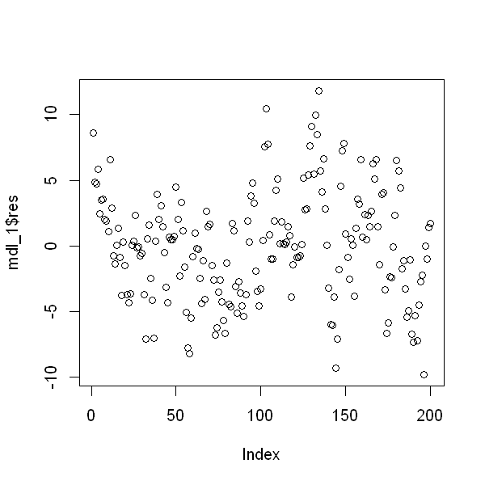

```r
plot(mdl_1$res)
```

The residuals plot shows signs of autocorrelation which is made more obvious if we smooth the pattern:

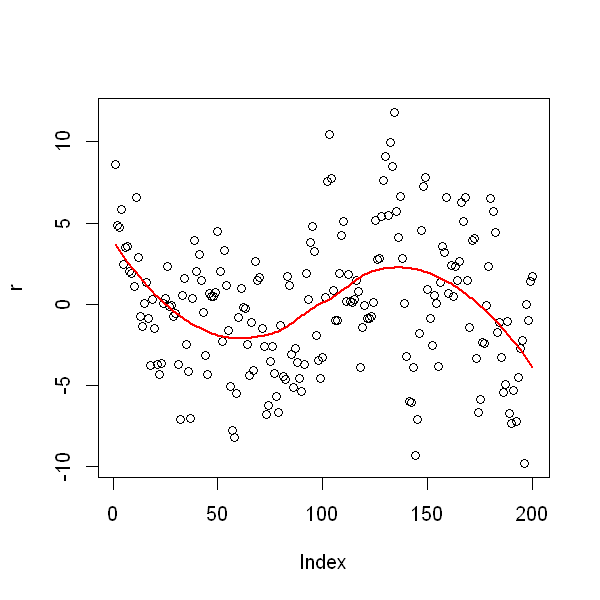

```r
r <- mdl_1$res
n<- 1:length(r)
plot(r)
lines(predict(loess(r~n)), col='red', lwd=2)
```

However, we cannot go by a visual inspection alone. Another option is to look at the [correlogram](https://en.wikipedia.org/wiki/Correlogram#:~:text=In%20the%20analysis%20of%20data,is%20called%20a%20cross%2Dcorrelogram.):

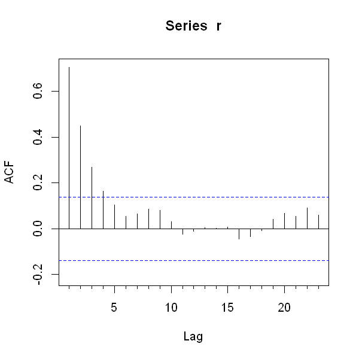

```r
Acf(r)
```

The correlogram indicates statistically significant autocorrelation coefficients at up to 4 lags. The sinusoidal pattern points to **positive autocorrelation.**

### The Durbin Watson test for autocorrelation

The Durbin Watson test is used to test the hypothesis that the residuals are serially correlated at lag 1 i.e. that in the following model: $$\epsilon_{i}=\rho \epsilon_{i-1}+v_{i}$$

the hypothesis tested $$\left\{\begin{array}{l}H_{0}: \rho=0 \\ H_{1}: \rho \neq 0\end{array}\right.$$

If we assume that $\sum_{i=2}^{N} \hat{\epsilon}_{i}^{2} \approx \sum_{i=2}^{N} \hat{\epsilon}_{i-1}^{2}$, then we can re-write the DW statistic as:

$$ D W=\frac{\sum_{i=2}^{N} \hat{\epsilon}_{i}^{2}-2 \sum_{i=2}^{N} \hat{\epsilon}_{i} \hat{\epsilon}_{i-1}+\sum_{i=2}^{N} \hat{\epsilon}_{i-1}^{2}}{\sum_{i=1}^{N} \hat{\epsilon}_{i}^{2}} \approx \frac{2\left[\sum_{i=2}^{N} \hat{\epsilon}_{i}^{2}-\sum_{i=2}^{N} \hat{\epsilon}_{i} \hat{\epsilon}_{i-1}\right]}{\sum_{i=1}^{N} \hat{\epsilon}_{i}^{2}}=2[1-\hat{\rho}(1)]= \begin{cases}4, & \text { if } \hat{\rho}(1)=-1 \\ 2, & \text { if } \hat{\rho}(1)=0 \\ 0, & \text { if } \hat{\rho}(1)=1\end{cases} $$

which helps in understanding why we expect the DW statistic to be close to 2 under the null hypothesis.

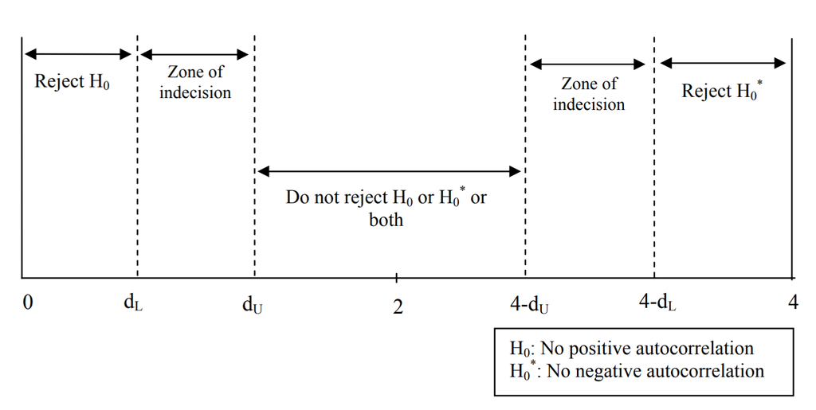

To run the DW test in R:

```r
dwtest(mdl_1)
```

```
	Durbin-Watson test

data:  mdl_1
DW = 0.56637, p-value < 2.2e-16
alternative hypothesis: true autocorrelation is greater than 0
```

The low and significant DW statistic points to positive serial correlation.

**Breusch-Godfrey (BG or LM) Test for autocorrelation.**

Alternately we can run the Breusch-Godfrey (BG or LM) which allows for flexibility on the number of lags tested.

$$\left\{\begin{array}{l}H_{0}: \rho_{1}=\ldots=\rho_{p}=0 \\ H_{1}: \rho_{j} \neq 0, \text { for some } j\end{array}\right.$$

To test the null hypothesis that at least on of the first three lags of the residuals is not zero:

```r
bg_t <- bgtest(mdl_1, order = 3)
print(bg_t)
```

```
	Breusch-Godfrey test for serial correlation of order up to 3

data:  mdl_1
LM test = 100.72, df = 3, p-value < 2.2e-16
```

Since the $p$ - value $<0.05$, we reject the null hypothesis and conclude that there is serial correlation in the residuals.

Knowing that OLS is inefficient in this case, we may calculate heteroskedasticity-and-autocorrelation-consistent (HAC) aka Newey-West standard errors to improve inferences.

```r
print(coeftest(mdl_1, sandwich::vcovHAC(mdl_1)))
```

```
t test of coefficients:

             Estimate Std. Error  t value  Pr(>|t|)
(Intercept) 10.616005   1.165046   9.1121 < 2.2e-16 ***
x1           4.890185   0.413444  11.8279 < 2.2e-16 ***
x2          -2.936860   0.060834 -48.2769 < 2.2e-16 ***
---
Signif. codes:  0 '***' 0.001 '**' 0.01 '*' 0.05 '.' 0.1 ' ' 1
```

Or we can invoke FGLS procedures such as the Cochrane Orcutt procedure:

```r
mdl_1_CORC <- cochrane.orcutt(mdl_1)
#
print(mdl_1_CORC$rho)
print(coef(summary(mdl_1_CORC)))
```

```
[1] 0.7088817
             Estimate Std. Error t value      Pr(>|t|)
(Intercept) 10.402800 1.50824063   6.897  7.124332e-11
x1           5.082365 0.48877934  10.398  1.899433e-20
x2          -2.978490 0.04202203 -70.879 1.185668e-141
```

Or the Prais–Winsten Procedure:

```r
mdl_1_pw <- prais_winsten(y ~ x1 + x2, data_mat,index = "time")
print(coef(summary(mdl_1_pw)))
```

```
Iteration 0: rho = 0
Iteration 1: rho = 0.7063
Iteration 2: rho = 0.7103
Iteration 3: rho = 0.7104
Iteration 4: rho = 0.7104
             Estimate Std. Error   t value      Pr(>|t|)
(Intercept) 11.428249  1.4459696   7.90352  1.882799e-13
x1           4.784759  0.4741705  10.09080  1.446391e-19
x2          -2.980398  0.0423427 -70.38752 1.389289e-141
```

### Conclusion: OLS vs serial correlation

What we have looked at so far is really **the old fashioned view** of the world as it comes to serial correlation in stationary time series – serial correlation causes a technical violation of an OLS assumption, leading to incorrect estimates of the standard errors. We then tried to find ways to deal with this ‘problem’. Here is an overview of what we found with no lagged variables:

- No serial correlation i.e. ρ = 0: OLS is just fine.
- With serial correlation: OLS leads to unbiased and consistent estimates of β. This is good. However, the standard errors are wrong. Thus, the OLS estimates are not efficient. A small amount of serial correlation only causes a small problem, but a large amount leads to large problems.
- If there is serial correlation, you could use GLS (Cochrane-Orcutt, Prais-Winsten). Alternatively, you could decide to simply use Newey-West standard errors.
- We need to be mindful that GLS and OLS with Newey-White standard errors can be quite biased if the correct model should include a lagged dependent variable.

## Modern View of Serial Correlation: Dynamic Models

Rather than see serial correlation as a technical violation of an OLS assumption, the modern view is to think of time series data in the context of market dynamics. Instead of mechanistically worrying about the residuals, we try to develop theories and use specifications that capture the dynamic processes in question. From this perspective, we view serial correlation as a potential sign of improper theoretical specification rather than a technical violation of an OLS assumption. This view of serial correlation leads us to look at ‘dynamic’ regression models where ‘dynamic’ refers to the inclusion of lagged (dependent and independent) variables.

There are two types of dynamic models: (i) distributed lag models and (ii) autoregressive models. Distributed lag models include lagged values of the independent variables, whereas autoregressive models include lagged values of the dependent variable.

**OLS Estimates of $A R(n)$ Models Are Biased**

- Consider the $A R(1)$ model $$ y_{t}=\rho y_{t-1}+\epsilon_{t} $$
- The OLS estimator for a sample of size $T$ is $$ \begin{aligned} \hat{\rho} &=\frac{\sum_{t=2}^{T} y_{t-1} (\rho y_{t-1}+\epsilon_{t})}{\sum_{t=2}^{T} y_{t-1}^{2}} \\ &=\rho+\frac{\sum_{t=2}^{T} y_{t-1} \epsilon_{t}}{\sum_{t=2}^{T} y_{t-1}^{2}} \\ &=\rho+\frac{\sum_{t=2}^{T} y_{t-1} \epsilon_{t}}{\sum_{t=2}^{T} y_{t-1}^{2}} \\ &=\rho+\sum_{t=2}^{T}\left(\frac{y_{t-1}}{\sum_{t=2}^{T} y_{t-1}^{2}}\right) \epsilon_{t} \end{aligned} $$

However under certain assumptions (weak/covariance stationarity) it can be shown that OLS is consistent.

With lagged dependent variables

- No serial correlation: OLS will be biased but consistent.
- With serial correlation: OLS estimates are not consistent and GLS fails because lagged dependent variable is correlated with the error term. Fortunately, models with lagged dependent variables do not often show serial correlation.
- OLS with lagged dependent variables still does relatively well when serial correlation is low.
- If serial correlation remains after the inclusion of a lagged dependent variable, one solution would be to add additional lagged terms.
- An alternative solution would be to use instrumental variables